# Repaso parcial 2

**NOTA:** El pseudo-código que se presenta en este documento no genera tal cual las gráficas o tablas resultantes. Los campos que se muestran rodeados con < > son *“placeholders”* para que sepan cuáles son las variables o argumentos que deben modificar. Por ejemplo, el primer pseudo-código mostrado

```r
train <- <dataframe> %>%
  filter(<condición para filtro>)
```

se sustituiría por algo como:

```r
train <- df %>%
  filter(Year <= 2019)
```

Bajo el supuesto de que sus datos estuvieran contenidos en la variable `df` y ésta tuviera una variable de tiempo llamada `Year`.

# Repaso teórico

Existen tres factores a considerar para ver qué tan bien se puede pronosticar una serie de tiempo:

1. Qué tan bien conocemos los factores o elementos que influyen en él.
2. Qué tantos datos tenemos disponibles.
3. Si el pronóstico que vamos a realizar puede influir en el resultado de la variable a predecir.

Si se determina que cumple con esas características, los pasos para llevar a cabo un proyecto de pronóstico, pueden enumerarse en los siguientes:

1. Preparación de los datos (limpieza)
2. Análisis exploratorio y gráfica de los datos (visualización)
3. Definición del modelo (especificación)
4. Entrenamiento del modelo (estimación)
5. Revisar el desempeño del modelo (evaluación)
6. Producir pronósticos

**NOTA**: Siempre que quieran revisar cómo funciona alguna función en particular, pueden consultar la documentación con el comando `help(<"función">)`.

## 1. Preparación de los datos (limpieza)

```r
library(easypackages)
packages("tidyverse","fpp3")
```

El `tidyverse` cuenta con paqueterías necesarias para la ciencia de datos. Por lo que, al cargar esta paquetería, podemos:

- **Importar datos**
  - Podemos utilizar las funciones dentro de la paquetería `readr`, como `read_csv()`, `read_delim()`, etc.
  - La paquetería `readxl` sirve para importar datos de Excel (.xls y .xlsx).
  - La paquetería `haven` cuenta con funiones para importar datos de SPSS, Stata, y SAS.
- **Manipulación de datos**
  - `tidyr`, `dplyr` tienen funciones para llevar a cabo la limplieza de datos.
  - `stringr` permite manipular variables de texto.
  - `forcats` ayuda a solucionar problemas con variables categóricas (factors).
  - `lubridate` a hacer transformaciones y operaciones con fechas.
  - `hms` sirve para valores de la hora del día.
- **Programación**
  - Para llevar a cabo iteraciones en objetos de **R**, es conveniente utilizar funciones de la paquetería `purrr`.

Siempre que queramos hacer pronósticos de una variable, debemos separar nuestros datos en dos conjuntos: datos de **entrenamiento** y datos de **prueba o pronóstico**. Para el ejemplo, nombraremos `train` al dataset filtrado que usaremos para el conjunto de entrenamiento.

Se recomienda que el tamaño del conjunto de prueba sea del 20% de la muestra, o del horizonte máximo de pronóstico que se requiere.

Para segmentar los datos podemos usar varias funciones como, de `dplyr`: `filter()`, `slice()`, y de `tsibble`: `filter_index()`.

Con `filter()`, las observaciones deben cumplir alguna condición:

```r
train <- <dataframe> %>%
  filter(<condición para filtro>)
```

Con `slice()`, se toman ciertas observaciones, de acuerdo a su posición en la tabla (índice):

```r
train <- <dataframe> %>%
  slice(<índice>)
```

`filter_index()` requiere que los datos sean un objeto `tsibble` y se especifica una fecha:

```r
train <- <dataframe> %>%
  filter_index(<fecha inicial> ~ <fecha final>)
```

Se puede definir usar todas las fechas desde el inicio hasta cierto punto o vice versa sustituyendo la `<fecha>` con un punto; `.`. P. ej., tomando como entrenamiento las fechas desde el inicio hasta cierta `<fecha final>`:

```r
train <- <dataframe> %>%
  filter_index(. ~ <fecha final>)
```

## 2. Análisis exploratorio y gráfica de los datos (visualización)

Se pueden hacer varios tipos de gráficas para el análisis exploratorio, siendo la elemental la gráfica de tiempo. Utilizamos la paquetería `ggplot2` para crear gráficos con diseño y capacidad muy amplia de personalización. La estructura básica para graficar con `ggplot2` se basa en la gramática de los gráficos, la cual consiste en:

- Llamar la función `ggplot()` para especificar el conjunto de datos a utilizar (*dataframe*).
- Definir la estética de la gráfica, en `aes()`. Esto es, las variables para los ejes (`x = <variable>`, `y = <variable>`), el color (`color = <variable>`), tamaño (`size = <variable>`), forma (`shape = <variable>`), relleno (`fill = <variable>`),etc.
- Establecer qué tipo o tipos de `geom` se van a utilizar para el gráfico (líneas, puntos, histogramas, boxplots, violín, etc.) con `geom_*`, donde el `*` puede ser `line`, `point`, `hist`, `boxplot`, `violin`, respectivamente.
- Se puede, opcionalmente, agregar más personalización al gráfico, como definir el título (con `ggtitle(<título>)`), títulos de ejes, escalas, entre otros.

**NOTA**: La estética se puede definir dentro de `ggplot(aes())`, lo que haría que esa estética aplique para todos los `geom` definidos, o dentro de cada `geom`, para que la estética cambie con cada uno.

Este ejemplo tomaría las mismas variables para las líneas y puntos:

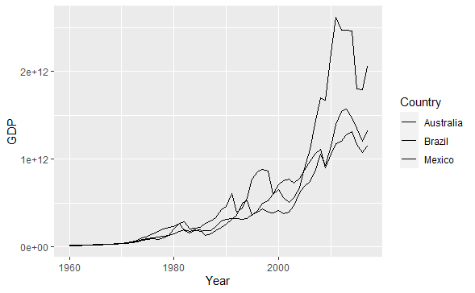

```r
<dataframe> %>%
  ggplot(aes(x = <variable>, y = <variable>,
                          color = <variable>, size = <variable>,
                          shape = <variable>, fill = <variable>)) +
         geom_line() +
         geom_point()
```

Este ejemplo tomaría distintas variables las líneas y puntos:

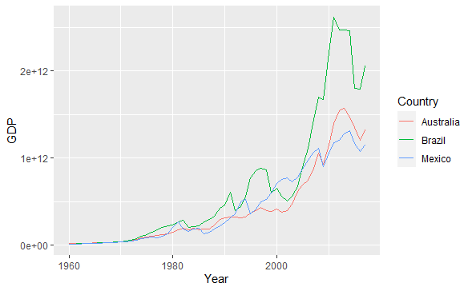

```r
<dataframe> %>%
  ggplot() +
         geom_line(aes(x = <variable>, y = <variable>,
                          color = <variable>, size = <variable>,
                          shape = <variable>, fill = <variable>)) +
         geom_point(aes(x = <variable>, y = <variable>,
                          color = <variable>, size = <variable>,
                          shape = <variable>, fill = <variable>))
```

### Gráfica de tiempo

Así una gráfica de tiempo tendría la estructura básica:

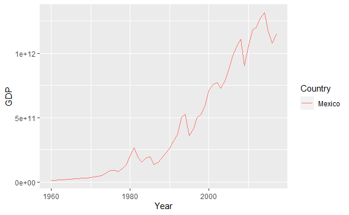

```r
<dataframe> %>%
  ggplot(aes(x = <variable de tiempo>, y = <variable>) +
         geom_line()
```

Si se quieren analizar los patrones de dos variables simultáneamente, se podría hacer algo como:

```r
<dataframe> %>%
  ggplot(<dataframe>, aes(x = <variable de tiempo>) +
           geom_line(aes(y = <variable1>), color = <color1>) +
           geom_line(aes(y = <variable2>), color = <color2>)
```

### Gráficos estacionales

```r
<dataframe> %>%
  gg_season()
```

```
Plot variable not specified, automatically selected `y = Employed`
```

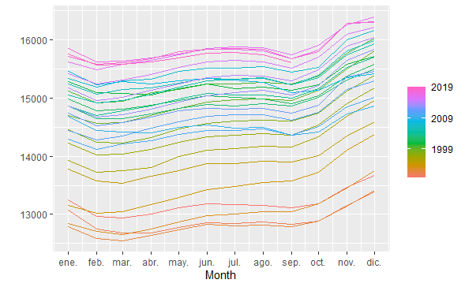

## 3 y 4. Definición y entrenamiento del modelo (especificación y estimación)

Hasta ahora, hemos visto solo los modelos de pronóstico que usaremos de referencia para evaluar los modelos más complejos. Estos son los métodos de:

- La Media; `MEAN()`.
- Ingenuo o Naïve; `NAIVE()`.
- Ingenuo estacional; `SNAIVE()`.
- Drift; `NAIVE(<var. dependiente> ~ drift())`.

Con la paquetería `fable` y `fabletools`, podemos estimar uno o más modelos de manera simultánea muy fácilmente. Para este ejemplo, guardaremos los modelos estimados en la variable `modelos` y utilizaremos los datos de entrenamiento para el ajuste:

```r
modelos <- <train> %>%
  model("nombre a darle al modelo1" = <modelo1>(<características del modelo1>,
        "nombre a darle al modelo2" = <modelo2>(<características del modelo2>)
```

Vimos también que se pueden ajustar modelos a variables transformadas matemáticamente, como con una transformación de Box-Cox. Si se realiza alguna transformación, debemos especificarla dentro del modelo:

```r
modelos <- <train> %>%
  model("nombre a darle al modelo1" = <modelo1>(<transformación>(<variable>))
```

## 5. Revisar el desempeño del modelo (evaluación)

Una vez ajustado el modelo, debemos asegurarnos de que hayamos logrado un buen ajuste. Esto lo podemos ver gráficamente y a través de pruebas estadísticas, al realizar diagnósticos de los residuos.

Primero, podemos graficar el ajuste del modelo a los datos (de entrenamiento). El ajuste de los datos lo podemos obtener con `augment()`, que nos arroja los datos ajustados `.fitted` y los residuos del modelo `.resid`. Guardaremos esto en la variable `aug`:

```r
<aug> <- modelos %>% augment()
```

Para graficar los datos de entrenamiento vs. el ajuste del modelo:

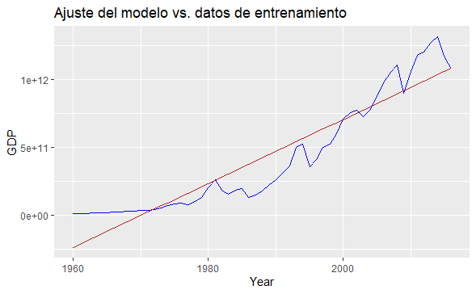

```r
<train> %>%
  ggplot(aes(x = <var. de tiempo>, y = <var. dependiente>))+
  geom_line(color = <color_datos_entrenamiento>)+
  geom_line(aes(y = <aug$.fitted>), color = <color_ajuste_modelo>)+
  ggtitle(<"título">)
```

Para realizar el diagnóstico de residuales:

```r
<modelos> %>% gg_tsresiduals() +
  ggtitle(<"título">)
```

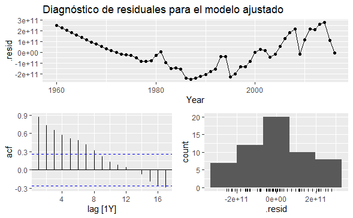

Lo que buscamos en estas gráficas es:

- Que en la primera no se perciba ningún patrón marcado, tendencia, etc., sino que los residuos se vean **aleatorios** y con **media cero**.
- Que la ACF muestre rezagos **no significativos**.
- Que el histograma muestre una distribución aproximadamente **normal**.

Para realizar las pruebas estadísticas de Box-Pierce y/o Ljung-Box:

```r
<aug> %>% features(.resid, box_pierce, lag=<10>, dof=<0>)
<aug> %>% features(.resid, ljung_box, lag=<10>, dof=<0>)
```

Lo sugerido para el valor del rezago en estas pruebas es:

- `lag = 10` cuando los datos son **no estacionales**.
- `lag = 2m` cuando son **estacionales**, donde $m$ es el periodo estacional.
- El valor de `dof` depende de los parámetros que se estén evaluando en el modelo. Para los modelos de referencia, al no tener parámetros a estimar, se utiliza `dof = 0`.

| Country | .model | lb_stat | lb_pvalue |
| --- | --- | --- | --- |
| Mexico | TSLM(GDP ~ trend()) | 181.9127 | 0 |

Si el p-value $< \alpha$, se rechaza la $H_0$ de la prueba ($H_0:$ *“Los residuos no están autocorrelacionados; los residuos son ruido blanco”*), por lo que, un modelo bien ajustado tendrá residuos que son ruido blanco y su prueba de Ljung-Box tendrá un p-value alto (mayor a $\alpha$).

## 6. Producir pronósticos

Generamos los pronósticos con la función `forecast()`. En ella debemos especificar algunos argumentos:

- `h`, o el horizonte de pronóstico.
- Si queremos que **R** realice el ajuste por sesgo (cuando se realiza una transformación matemática). Por defaúlt está marcado que **sí realice el ajuste por sesgo**, `bias_adjust = TRUE`.
- Si queremos que el pronóstico genere intervalos de predicción normales o mediante **bootstrap**. Por defáult no genera intervalos con bootstrap, hay que especificarlo: `bootstrap = TRUE`.

Guardamos el pronostico en la variable `fc` para los siguientes `h` periodos:

```r
<fc> <- modelos %>%
  forecast( h = <h>)

<fc> %>%
  autoplot(<dataframe>, level = NULL)
```

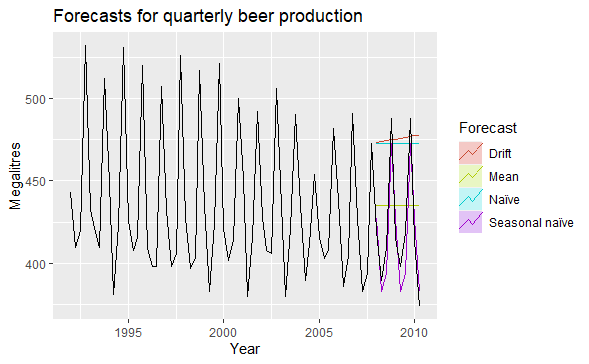

Y para medir la precisión del pronóstico, calculamos los errores con `accuracy()`. El modelo que obtenga el menor error será el mejor:

```r
accuracy(<fc>, <dataframe>)
```

| .model | .type | ME | RMSE | MAE | MPE | MAPE | MASE | ACF1 |
| --- | --- | --- | --- | --- | --- | --- | --- | --- |
| Drift | Test | -54.01905 | 64.90129 | 58.87619 | -13.582171 | 14.577487 | 4.1172161 | -0.07410793 |
| Mean | Test | -13.77500 | 38.44724 | 34.82500 | -3.969866 | 8.283390 | 2.4353147 | -0.06905715 |
| Naïve | Test | -51.40000 | 62.69290 | 57.40000 | -12.954916 | 14.184424 | 4.0139860 | -0.06905715 |
| Seasonal naïve | Test | 5.20000 | 14.31084 | 13.40000 | 1.147554 | 3.168503 | 0.9370629 | 0.13184068 |

# Tarea

## Ejercicios

### Problema 1

*Produzcan pronósticos de las siguientes series de tiempo, utilizando el modelo que consideren más apropiado para cada caso entre `NAIVE()`, `SNAIVE()` o `RW( ~ drift())`:*

#### * Población australiana (`global_economy`)

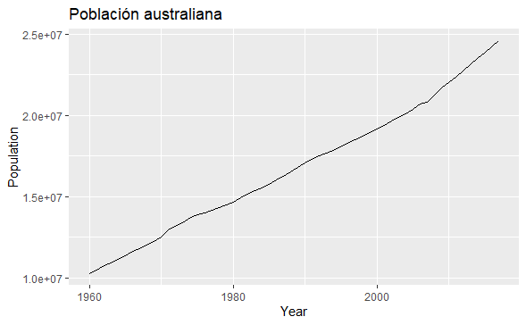

```r
aus_pop <- global_economy %>%
  filter(Country == "Australia")

aus_pop %>%
  ggplot(aes(x = Year, y = Population))+
  geom_line() + ggtitle("Población australiana")
```

Como la población parece aumentar de manera bastante lineal, probamos con el método del **drift**.

```r
# Separar los datos en entrenamiento y prueba
aus_pop_train <- aus_pop %>%
  slice(1:trunc(n()*.8,0))

# Ajuste del modelo
aus_pop_model <- aus_pop_train %>%
  model(RW(Population ~ drift()))

# Obtener residuales y valores ajustados
aus_pop_aug <- aus_pop_model %>% augment()

aus_pop_aug
```

| Country | .model | Year | Population | .fitted | .resid |
| --- | --- | --- | --- | --- | --- |
| Australia | RW(Population ~ drift()) | 1960 | 10276477 | NA | NA |
| Australia | RW(Population ~ drift()) | 1961 | 10483000 | 10501329 | -18328.622 |
| Australia | RW(Population ~ drift()) | 1962 | 10742000 | 10707852 | 34148.378 |
| Australia | RW(Population ~ drift()) | 1963 | 10950000 | 10966852 | -16851.622 |
| Australia | RW(Population ~ drift()) | 1964 | 11167000 | 11174852 | -7851.622 |
| Australia | RW(Population ~ drift()) | 1965 | 11388000 | 11391852 | -3851.622 |
| Australia | RW(Population ~ drift()) | 1966 | 11651000 | 11612852 | 38148.378 |
| Australia | RW(Population ~ drift()) | 1967 | 11799000 | 11875852 | -76851.622 |
| Australia | RW(Population ~ drift()) | 1968 | 12009000 | 12023852 | -14851.622 |
| Australia | RW(Population ~ drift()) | 1969 | 12263000 | 12233852 | 29148.378 |

[output cut: 36 more lines]

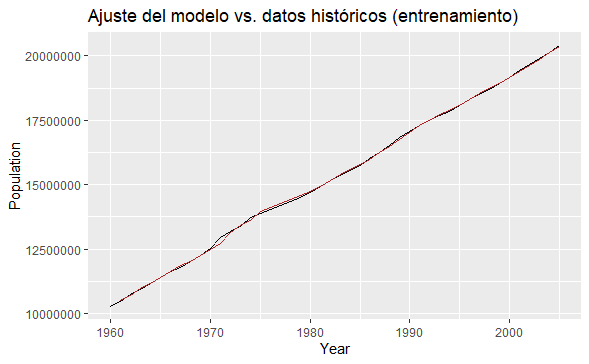

```r
# Gráfica
aus_pop_train %>%
  ggplot(aes(x = Year, y = Population))+
  geom_line()+
  geom_line(aes(y = aus_pop_aug$.fitted),color = "firebrick")+
  ggtitle("Ajuste del modelo vs. datos históricos (entrenamiento)")
```

El pronóstico:

```r
aus_pop_fc <- aus_pop_model %>%
  forecast(h = length(aus_pop$Year)-length(aus_pop_train$Year))
aus_pop_fc
```

| Country | .model | Year | Population | .distribution |
| --- | --- | --- | --- | --- |
| Australia | RW(Population ~ drift()) | 2006 | 20619652 |  |
| Australia | RW(Population ~ drift()) | 2007 | 20844503 |  |
| Australia | RW(Population ~ drift()) | 2008 | 21069355 |  |
| Australia | RW(Population ~ drift()) | 2009 | 21294206 |  |
| Australia | RW(Population ~ drift()) | 2010 | 21519058 |  |
| Australia | RW(Population ~ drift()) | 2011 | 21743910 |  |
| Australia | RW(Population ~ drift()) | 2012 | 21968761 |  |
| Australia | RW(Population ~ drift()) | 2013 | 22193613 |  |
| Australia | RW(Population ~ drift()) | 2014 | 22418465 |  |
| Australia | RW(Population ~ drift()) | 2015 | 22643316 |  |

[output cut: 2 more lines]

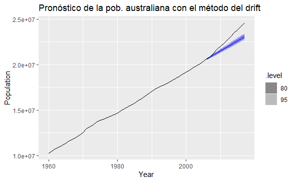

```r
aus_pop_fc %>%
  autoplot(aus_pop) + ggtitle("Pronóstico de la pob. australiana con el método del drift")
```

#### * Producción de ladrillos (Bricks de `aus_production`)

```r
bricks <- aus_production %>%
  select(Quarter, Bricks) %>%
  na.omit() %>%  # para quitar los NAs que tiene la serie al final
  as_tsibble()
```

```
Using `Quarter` as index variable.
```

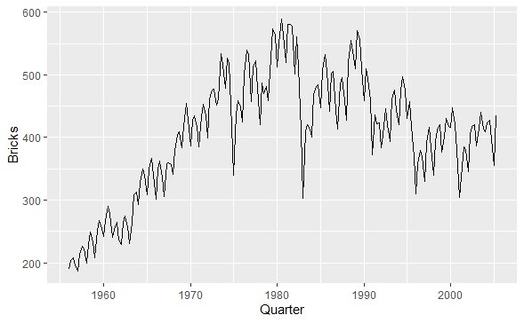

```r
# Gráfica de los datos

ggplot(bricks, aes(x = Quarter, y = Bricks)) +
  geom_line()
```

```r
# Separar los datos en entrenamiento y prueba
bricks_train <- bricks %>%
  slice(1:trunc(n()*.8,0))

# Ajuste del modelo
bricks_model <- bricks_train %>%
  model(seasonal_naive = SNAIVE(Bricks))

# Obtener residuales y valores ajustados
bricks_aug <- bricks_model %>% augment()

bricks_aug
```

| .model | Quarter | Bricks | .fitted | .resid |
| --- | --- | --- | --- | --- |
| seasonal_naive | 1956 Q1 | 189 | NA | NA |
| seasonal_naive | 1956 Q2 | 204 | NA | NA |
| seasonal_naive | 1956 Q3 | 208 | NA | NA |
| seasonal_naive | 1956 Q4 | 197 | NA | NA |
| seasonal_naive | 1957 Q1 | 187 | 189 | -2 |
| seasonal_naive | 1957 Q2 | 214 | 204 | 10 |
| seasonal_naive | 1957 Q3 | 227 | 208 | 19 |
| seasonal_naive | 1957 Q4 | 222 | 197 | 25 |
| seasonal_naive | 1958 Q1 | 199 | 187 | 12 |
| seasonal_naive | 1958 Q2 | 229 | 214 | 15 |

[output cut: 148 more lines]

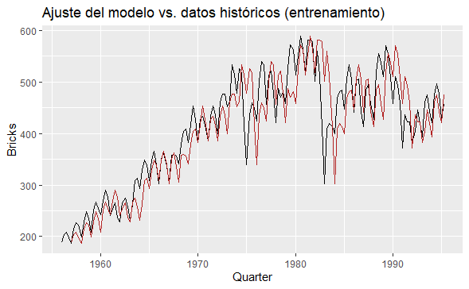

```r
# Gráfica
bricks_train %>%
  ggplot(aes(x = Quarter, y = Bricks))+
  geom_line()+
  geom_line(aes(y = bricks_aug$.fitted),color = "firebrick")+
  ggtitle("Ajuste del modelo vs. datos históricos (entrenamiento)")
```

El pronóstico:

```r
bricks_fc <- bricks_model %>%
  forecast(h = length(bricks$Quarter)-length(bricks_train$Quarter))
bricks_fc
```

| .model | Quarter | Bricks | .distribution |
| --- | --- | --- | --- |
| seasonal_naive | 1995 Q3 | 497 |  |
| seasonal_naive | 1995 Q4 | 476 |  |
| seasonal_naive | 1996 Q1 | 430 |  |
| seasonal_naive | 1996 Q2 | 457 |  |
| seasonal_naive | 1996 Q3 | 497 |  |
| seasonal_naive | 1996 Q4 | 476 |  |
| seasonal_naive | 1997 Q1 | 430 |  |
| seasonal_naive | 1997 Q2 | 457 |  |
| seasonal_naive | 1997 Q3 | 497 |  |
| seasonal_naive | 1997 Q4 | 476 |  |

[output cut: 30 more lines]

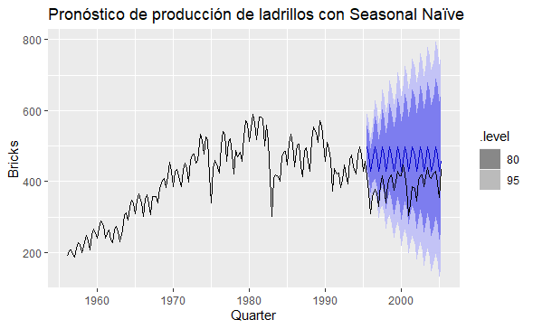

```r
bricks_fc %>%
  autoplot(bricks) + ggtitle("Pronóstico de producción de ladrillos con Seasonal Naïve")
```